# Reproducible Research Assignment 2: Fatalities and Economic Damage from Environment

Sammie Bae

April 26, 2016

# Project:

## Investigating Fatalities and Economic Damage from Environment using data from U.S. National Oceanic and Atmospheric Administration’s (NOAA) storm database (1950 - 2011)

# Synopsis:

### Storms and other severe weather events can cause both public health and economic problems for communities and municipalities. Many severe events can result in fatalities, injuries, and property damage, and preventing such outcomes to the extent possible is a key concern.

### This project involves exploring the U.S. National Oceanic and Atmospheric Administration’s (NOAA) storm database. This analysis will explore which environmental events caused the most death and economic damage

### It can be concluded for both number of deaths and highest economical damage that tornado is the most harmful event

# Data Processing:

Download the data from url if it doesn’t exist in directory

```r
setwd("C:\\Users\\Sam.E\\Desktop\\datasciencecoursera\\Reproducible Research\\Assignment 2")
  getwd()
```

```
## [1] "C:/Users/Sam.E/Desktop/datasciencecoursera/Reproducible Research/Assignment 2"
```

```r
  fileName <- "repdata-data-StormData.csv.bz2"
```

Download

```r
  if (!file.exists(fileName)){
    downloadURL <-"https://d396qusza40orc.cloudfront.net/repdata%2Fdata%2FStormData.csv.bz2"
    f <- file.path(getwd(), "repdata-data-StormData.csv.bz2")
    download.file(downloadURL, f)
  }
```

Unzip it

```r
  if (!file.exists("repdata-data-StormData.csv")) {
    unzip(fileName)
  }
```

read the CSV data

```r
  repData <- read.csv("repdata-data-StormData.csv")
```

# Data Analysis

1. Across the United States, which types of events (as indicated in the EVTYPE variable) are most harmful with respect to population health?

```r
  library(ggplot2)
  repData$EVTYPE = toupper(repData$EVTYPE)
  dim(repData)
```

```
## [1] 902297     37
```

```r
  #aggregate by EVTYPE and FATALITIES
  aggFatalrepData <- aggregate(FATALITIES ~ EVTYPE, data = repData, sum)
  #fatal greater than 0
  fatalData <- aggFatalrepData[aggFatalrepData$FATALITIES > 0, ]
  #order descending
  fatalOrder <- fatalData[order(fatalData$FATALITIES, decreasing = TRUE), ]
  head(fatalOrder)
```

```
##             EVTYPE FATALITIES
## 758        TORNADO       5633
## 116 EXCESSIVE HEAT       1903
## 138    FLASH FLOOD        978
## 243           HEAT        937
## 418      LIGHTNING        816
## 779      TSTM WIND        504
```

```r
  #highest fatalities
  fatalOrder[1,]
```

```
##      EVTYPE FATALITIES
## 758 TORNADO       5633
```

### Answer: Clearly from the descendingly ordering the data by fatalities and graphing it, Tornado caused most number of deaths

2. Across the United States, which types of events have the greatest economic consequences?

```r
  library(ggplot2)
  names(repData)
```

```
##  [1] "STATE__"    "BGN_DATE"   "BGN_TIME"   "TIME_ZONE"  "COUNTY"
##  [6] "COUNTYNAME" "STATE"      "EVTYPE"     "BGN_RANGE"  "BGN_AZI"
## [11] "BGN_LOCATI" "END_DATE"   "END_TIME"   "COUNTY_END" "COUNTYENDN"
## [16] "END_RANGE"  "END_AZI"    "END_LOCATI" "LENGTH"     "WIDTH"
## [21] "F"          "MAG"        "FATALITIES" "INJURIES"   "PROPDMG"
## [26] "PROPDMGEXP" "CROPDMG"    "CROPDMGEXP" "WFO"        "STATEOFFIC"
## [31] "ZONENAMES"  "LATITUDE"   "LONGITUDE"  "LATITUDE_E" "LONGITUDE_"
## [36] "REMARKS"    "REFNUM"
```

```r
  #economic damage PROPDMG

  #aggregate by EVTYPE and PROPDMG
  aggDMGrepData <- aggregate(PROPDMG ~ EVTYPE, data = repData, sum)
  #damage greater than 0
  DMGrepData <- aggDMGrepData[aggDMGrepData$PROPDMG > 0,]
  #order descending
  DMGrepOrder<- DMGrepData[order(DMGrepData$PROPDMG, decreasing = TRUE), ]
  head(DMGrepOrder)
```

```
##                EVTYPE   PROPDMG
## 758           TORNADO 3212258.2
## 138       FLASH FLOOD 1420124.6
## 779         TSTM WIND 1335995.6
## 154             FLOOD  899938.5
## 685 THUNDERSTORM WIND  876844.2
## 212              HAIL  688693.4
```

```r
  #highest damage
  DMGrepOrder[1,]
```

```
##      EVTYPE PROPDMG
## 758 TORNADO 3212258
```

### Answer: Clearly from the descendingly ordering the data by economic damage and graphing it, Tornado caused most economic damage

# Result

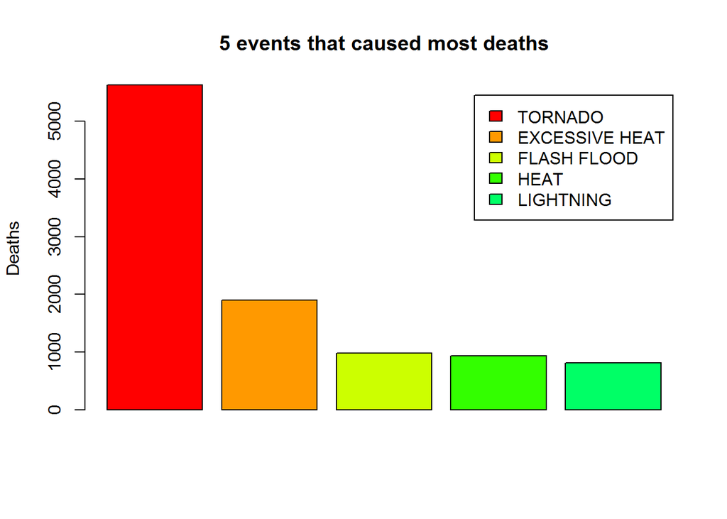

```r
  topFatal <- fatalOrder[1:5,]
  barplot(topFatal[,2], col = rainbow(10), legend.text = topFatal[,1],
          ylab = "Deaths", main = "5 events that caused most deaths")
```

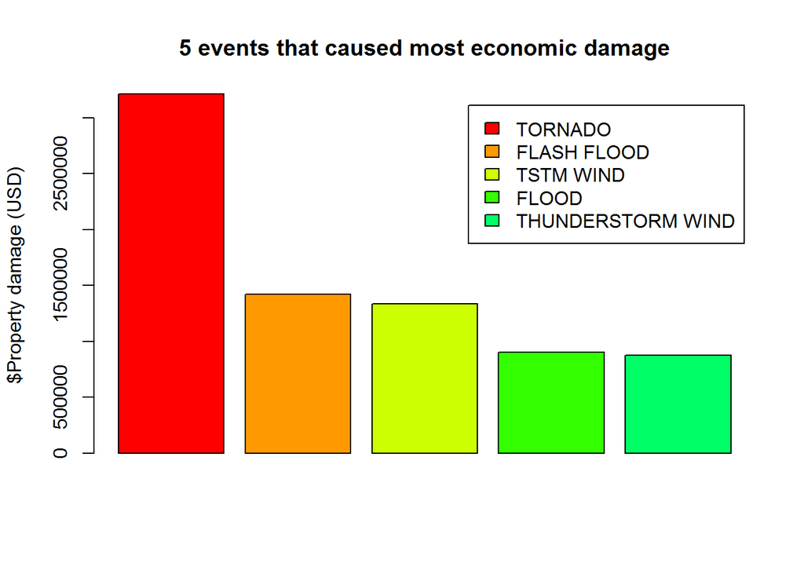

```r
  topDMG <- DMGrepOrder[1:5,]
  barplot(topDMG[,2], col = rainbow(10), legend.text = topDMG[,1],
          ylab = "$Property damage (USD)", main = "5 events that caused most economic damage")
```

# Conclusion

## As seen from both graphs, tornado casused the most deaths and economic damage